# 合租模式下的租房价格分析

梁之扬 19307130184

## 数据读入与汇总统计

```r
df <- read.csv(file = "data.csv",fileEncoding = 'utf-8',as.is = F)
kable(summary(df))
```

|  | rent | bedroom | livingroom | bathroom | area | room | floor_grp | subway | region | heating |
| --- | --- | --- | --- | --- | --- | --- | --- | --- | --- | --- |
|  | Min. :1150 | Min. :2.000 | Min. :1.00 | Min. :1.000 | Min. : 5.00 | 主卧:2289 | 中楼层:1878 | 否: 815 | 朝阳 :1317 | 自采暖 : 952 |
|  | 1st Qu.:2240 | 1st Qu.:2.000 | 1st Qu.:1.00 | 1st Qu.:1.000 | 1st Qu.:10.00 | 次卧:2860 | 低楼层:1679 | 是:4334 | 通州 : 819 | 集中供暖:4197 |
|  | Median :2690 | Median :3.000 | Median :1.00 | Median :1.000 | Median :12.00 | NA | 高楼层:1592 | NA | 昌平 : 702 | NA |
|  | Mean :2798 | Mean :2.996 | Mean :1.01 | Mean :1.027 | Mean :12.85 | NA | NA | NA | 丰台 : 581 | NA |
|  | 3rd Qu.:3230 | 3rd Qu.:4.000 | 3rd Qu.:1.00 | 3rd Qu.:1.000 | 3rd Qu.:15.00 | NA | NA | NA | 海淀 : 424 | NA |
|  | Max. :6460 | Max. :5.000 | Max. :2.00 | Max. :2.000 | Max. :30.00 | NA | NA | NA | 大兴 : 361 | NA |
|  | NA | NA | NA | NA | NA | NA | NA | NA | (Other): 945 | NA |

## 月租金分布情况

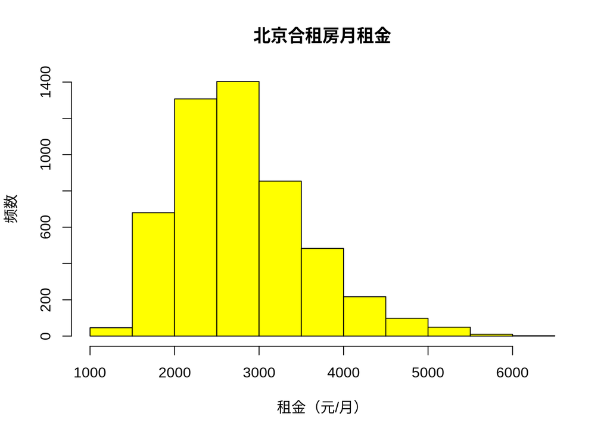

```r
hist(df$rent, col = '#FFFF00', main = '北京合租房月租金', xlab = '租金（元/月）',ylab = '频数')
```

结合汇总统计以及直方图，我们可以看出，月租金在1150元以上，6460元以下，2000元至3000元的区间内分布较多，整体呈现右偏的状态，说明合租房中也可能存在“高端类型”。

## 不同城区租房平均价格

```r
sort(tapply(df$rent, df$region, mean), decreasing = T)
```

```
##     西城     海淀     朝阳     东城   石景山     丰台     昌平     通州
## 3784.792 3490.920 3302.103 3262.872 2819.845 2734.286 2693.376 2327.216
##     大兴     顺义     房山
## 2241.136 2111.497 1751.257
```

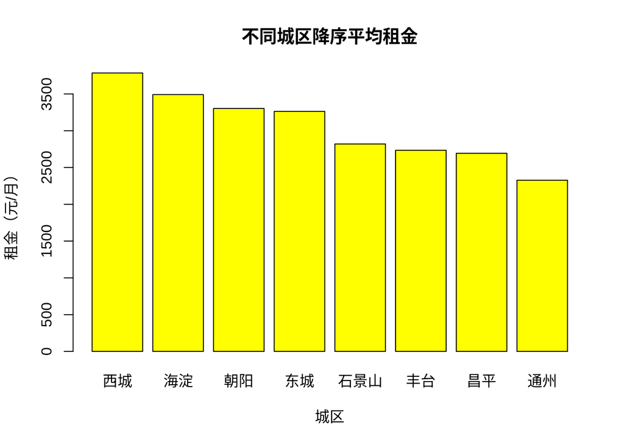

```r
avg <- sort(tapply(df$rent, df$region, mean), decreasing = T)
barplot(avg[1:8], xlab = '城区', ylab = '租金（元/月）', col = '#FFFF00', main = '不同城区降序平均租金')
```

北京各区平均月租金最高的是西城区，达到了3784.792元，最低的房山区月租金为1751.257元。通过上图可将北京不同城区合租房月租金进行分组：西城区独一组；海淀，朝阳，东城为第二组；石景山，丰台，昌平为第三组。组内租金相近，组间租金呈现阶梯式下降趋势。推测这可能与地理位置有关，在同一环线上的区租金相仿，更靠近内环的区租金更高。

## 月租金-城区 分组箱线图

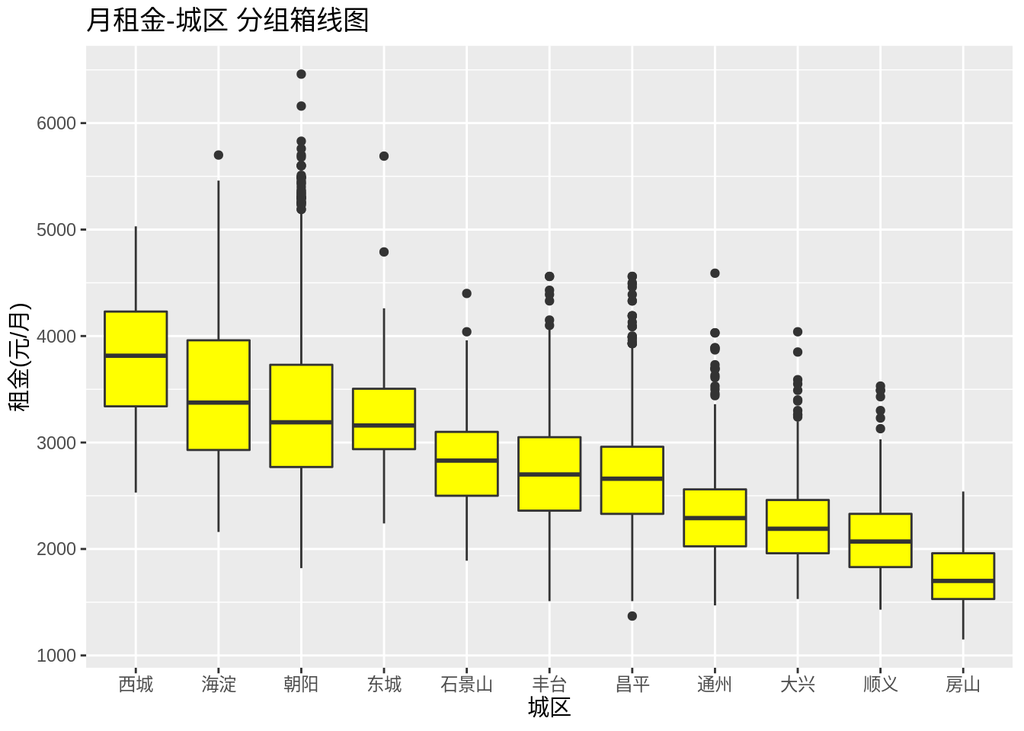

```r
ggplot(df, aes(x=reorder(region, -rent, mean), y=rent)) +
  geom_boxplot(fill = '#FFFF00') + labs(title='月租金-城区 分组箱线图',x='城区', y = '租金(元/月)')
```

这里我们同样按照均值进行对箱线图排序，方便我们的观察：

通过箱线图我们可以更明显地看出不同城区平均月租金呈现按组别变化的趋势，更进一步，我们可以看出朝阳，海淀和西城月租金分布较广，而其余城区则相对分布更加集中。

值得注意的是，朝阳区存在较多离群值，很有可能是在国贸和望京周边上班的人偏向租离单位更近的房子，自然价格就会更高；而相对外围的丰台，昌平，通州，大兴等地存在离群值的原因就可能有所不同，更有可能是用于休闲聚会的民宿。

## 以月租金作为因变量，其余变量为自变量建立线性回归模型并分析

```r
# 租赁房间变量以“次卧”作为基准组
df$room <- factor(df$room, levels = c("次卧", "主卧"))
# 所在楼层分组变量以“低楼层”作为基准组
df$floor_grp <- factor(df$floor_grp, levels = c("低楼层", "中楼层", "高楼层"))
# 邻近地铁变量以“否”作为基准组
df$subway <- factor(df$subway, levels = c("否", "是"))
# 城区变量以“石景山”作为基准组
df$region <- factor(df$region, levels = c("石景山", "房山", "顺义", "大兴", "通州", "昌平", "丰台", "东城", "朝阳", "海淀", "西城"))
# 供暖方式变量以“自采暖”作为基准组
df$heating <- factor(df$heating, levels = c("自采暖", "集中供暖"))
lm1 <- lm(formula = rent ~ ., data = df)
summary(lm1)
```

```
##
## Call:
## lm(formula = rent ~ ., data = df)
##
## Residuals:
##      Min       1Q   Median       3Q      Max
## -1617.48  -275.26   -23.21   248.40  2967.39
##
## Coefficients:
##                   Estimate Std. Error t value Pr(>|t|)
## (Intercept)     1593.22405   79.93979  19.930  < 2e-16 ***
## bedroom          -90.55187    8.73965 -10.361  < 2e-16 ***
## livingroom      -168.01859   71.84304  -2.339 0.019390 *
## bathroom         182.10825   43.63344   4.174 3.05e-05 ***
## area              76.69198    1.96317  39.065  < 2e-16 ***
## room主卧           0.08443   16.57165   0.005 0.995935
## floor_grp中楼层  -55.59610   15.29704  -3.634 0.000281 ***
## floor_grp高楼层  -24.98532   15.95019  -1.566 0.117303
## subway是         280.44440   17.73655  15.812  < 2e-16 ***
## region房山      -811.82173   45.02264 -18.031  < 2e-16 ***
## region顺义      -450.95937   39.11271 -11.530  < 2e-16 ***
## region大兴      -421.98157   37.42529 -11.275  < 2e-16 ***
## region通州      -373.00568   32.65046 -11.424  < 2e-16 ***
## region昌平        57.19973   34.07111   1.679 0.093245 .
## region丰台       117.59678   34.57808   3.401 0.000677 ***
## region东城       565.01670   55.05629  10.263  < 2e-16 ***
## region朝阳       631.69500   31.69727  19.929  < 2e-16 ***
## region海淀       878.86347   36.51087  24.071  < 2e-16 ***
## region西城       938.86226   54.33181  17.280  < 2e-16 ***
## heating集中供暖  155.79086   17.13452   9.092  < 2e-16 ***
## ---
## Signif. codes:  0 '***' 0.001 '**' 0.01 '*' 0.05 '.' 0.1 ' ' 1
##
## Residual standard error: 454.1 on 5129 degrees of freedom
## Multiple R-squared:  0.6466, Adjusted R-squared:  0.6453
## F-statistic: 493.9 on 19 and 5129 DF,  p-value: < 2.2e-16
```

与上课类似，我们绘制表格整理得到的结果：

[output not shown]

控制其余因素不变的情况下，可以初步得到如下结论：

$\cdot$每增加一间卧室，月租金下降90.552元；

$\cdot$每增加一间客厅，月租金下降168.019元；

$\cdot$每增加一间卫生间，月租金上升182.108元；

$\cdot$房屋面积每增加一平方米，月租金上升76.692元；

$\cdot$主卧租金高于次卧；

$\cdot$所在楼层低楼层的租金最高，高楼层次之，中楼层租金最低；

$\cdot$邻近地铁租金更高；

$\cdot$石景山的房屋月租金高于房山，顺义，大兴，通州，低于昌平，丰台，东城，朝阳，海淀，西城；

$\cdot$集中供暖租金要比自采暖更高。

## BIC变量选择

```r
# 做对数变换即从AIC变成了BIC
lm2 <- step(lm1, direction = 'both', k = log(dim(df)[1]))
```

```r
summary(lm2)
```

```
##
## Call:
## lm(formula = rent ~ bedroom + bathroom + area + subway + region +
##     heating, data = df)
##
## Residuals:
##      Min       1Q   Median       3Q      Max
## -1611.79  -271.91   -25.92   248.37  2980.50
##
## Coefficients:
##                 Estimate Std. Error t value Pr(>|t|)
## (Intercept)     1440.449     59.027  24.403  < 2e-16 ***
## bedroom          -91.457      8.547 -10.701  < 2e-16 ***
## bathroom         141.751     40.550   3.496 0.000477 ***
## area              76.527      1.533  49.930  < 2e-16 ***
## subway是         281.206     17.743  15.849  < 2e-16 ***
## region房山      -808.478     45.011 -17.962  < 2e-16 ***
## region顺义      -456.412     39.038 -11.691  < 2e-16 ***
## region大兴      -418.866     37.422 -11.193  < 2e-16 ***
## region通州      -372.159     32.685 -11.386  < 2e-16 ***
## region昌平        58.700     34.104   1.721 0.085276 .
## region丰台       119.461     34.606   3.452 0.000561 ***
## region东城       565.767     55.124  10.264  < 2e-16 ***
## region朝阳       634.860     31.729  20.009  < 2e-16 ***
## region海淀       880.960     36.546  24.106  < 2e-16 ***
## region西城       935.072     54.387  17.193  < 2e-16 ***
## heating集中供暖  154.970     17.150   9.036  < 2e-16 ***
## ---
## Signif. codes:  0 '***' 0.001 '**' 0.01 '*' 0.05 '.' 0.1 ' ' 1
##
## Residual standard error: 454.7 on 5133 degrees of freedom
## Multiple R-squared:  0.6453, Adjusted R-squared:  0.6443
## F-statistic: 622.7 on 15 and 5133 DF,  p-value: < 2.2e-16
```

同样绘制表格整理结果如下：

| 变量 | 回归系数 | p值 | 备注 |
| --- | --- | --- | --- |
| 截距项 | 1440.449 | <2e-16 |  |
| 卧室数 | -91.457 | <2e-16 |  |
| 卫生间数 | 141.751 | 0.000477 |  |
| 房间面积 | 76.527 | <2e-16 |  |
| 邻近地铁：是 | 281.206 | <2e-16 | 基准组：否 |
| 所在城区：房山 所在城区：顺义 所在城区：大兴 所在城区：通州 所在城区：昌平 所在城区：丰台 所在城区：东城 所在城区：朝阳 所在城区：海淀 所在城区：西城 | -808.478 -456.412 -418.866 -372.159 58.700 119.461 565.767 634.860 880.960 935.072 | <2e-16 <2e-16 <2e-16 <2e-16 0.0853 0.000561 <2e-16 <2e-16 <2e-16 <2e-16 | 基准组：石景山 |
| 供暖方式：集中供暖 | 154.970 | <2e-16 | 基准组：自采暖 |
| F检验 | p值<2.2e-16 | Adjusted $R^2$ | 0.6443 |

## 五折交叉验证

```r
# 使用DAAG包实现五折交叉验证,这里隐藏不必要的输出
cvlm2 = cv.lm(data = df, lm2, m = 5, printit = F, seed = 1234)
```

```r
attr(cvlm2, 'ms')
```

```
## [1] 208261.6
```

由五折交叉验证的结果，我们可以看出线性模型的拟合结果较差，为改善这一问题，我们进行模型诊断：

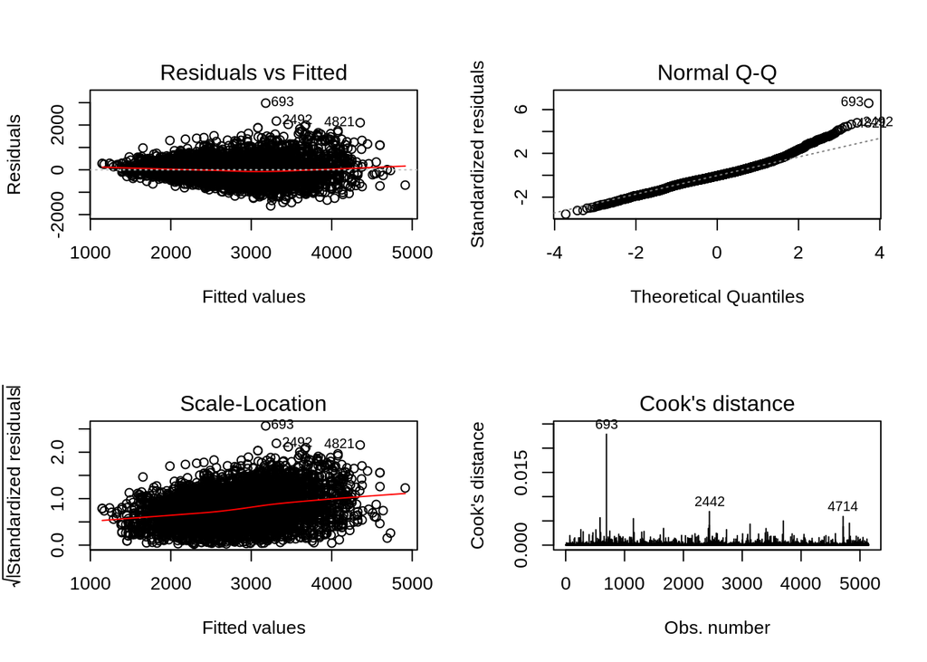

```r
par(mfrow = c(2,2))
plot(lm2,which=c(1:4))
```

根据模型诊断图我们发现模型拟合效果欠佳，异方差性较为明显，同时尾部正态性不佳，有改进空间，故使用对数线性模型进行改进：

```r
# 构建对数线性回归模型
lm3 <- lm(formula = log(rent)~ .,data = df)
# 同样使用BIC准则进行筛选
lm4 <- step(lm3, direction = 'both', k = log(dim(df)[1]))
# 五折交叉验证
cvlm4 = cv.lm(data = df, lm4, m = 5, printit = F, seed = 1234)
```

```r
attr(cvlm4, 'ms')
```

```
## [1] 0.02324097
```

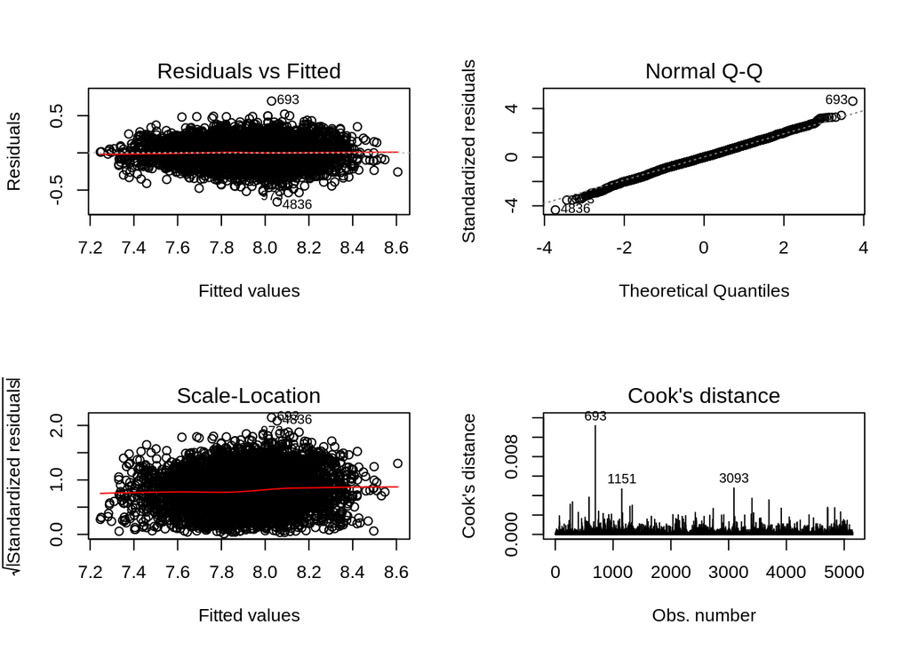

```r
par(mfrow = c(2,2))
plot(lm4,which=c(1:4))
```

同样从模型诊断图上来看，建立对数线性模型后，异方差和无正态性的情况都得到了较好的改善。这也同时说明五折交叉验证是帮助我们判断模型优劣的有力手段。